# EDA: Salaries of MLB Batters from 1985 to 2020

##### F. GIDP

This logic is similar to `GIDP`, or “grounded in double play” counts/rates.

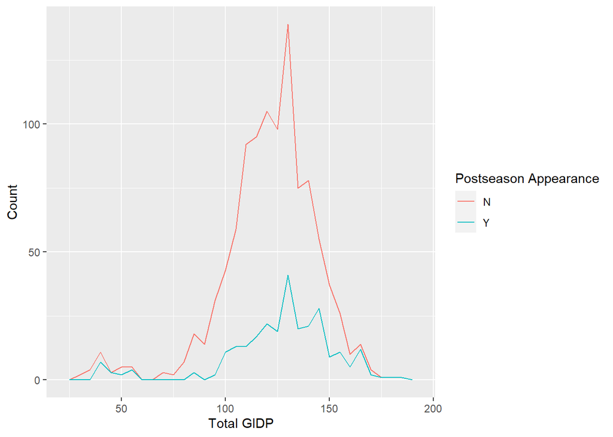

```r
teamsummary %>%
  ggplot(mapping = aes(x = total_GIDP)) +
  geom_freqpoly(mapping = aes(colour = postseason_app), binwidth = 5) +
  labs(x = "Total GIDP", y = "Count", colour = "Postseason Appearance")
```

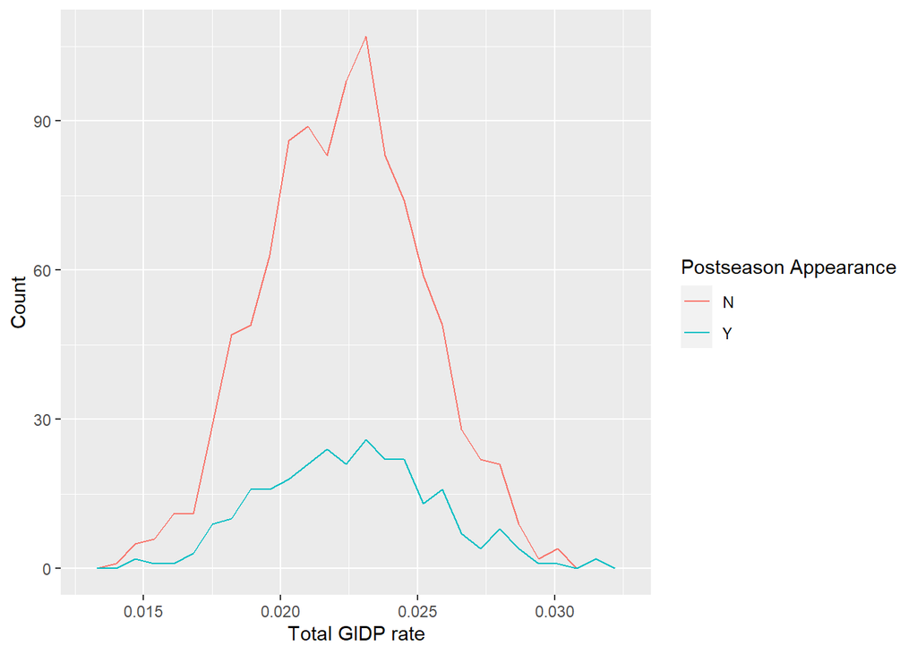

```r
teamsummary %>%
  ggplot(mapping = aes(x = total_GIDPperc)) +
  geom_freqpoly(mapping = aes(colour = postseason_app), binwidth = 0.0007) +
  labs(x = "Total GIDP rate", y = "Count", colour = "Postseason Appearance")
```

Both strikeout counts/rates and GIDP counts/rates are not as great predictor of a team’s postseason appearance likelihood, compared to the number of runs and home runs that a team accumulates throughout the season.  
These scatterplots confirm that runs matter more than K rate and GIDP rate in determining a team’s postseason appearance likelihood.

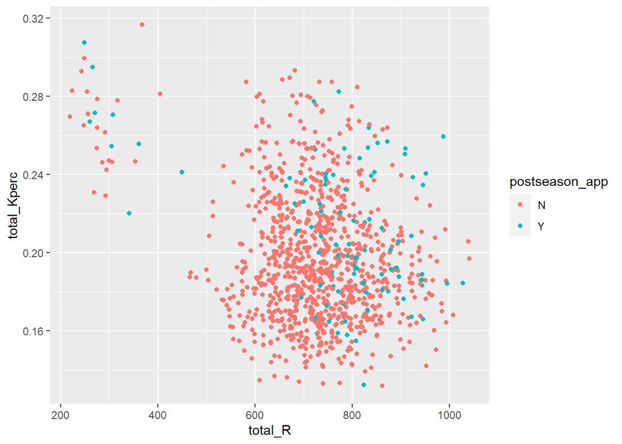

```r
teamsummary %>%
  ggplot(mapping = aes(x = total_R, y = total_Kperc)) +
  geom_point(aes(colour = postseason_app))
```

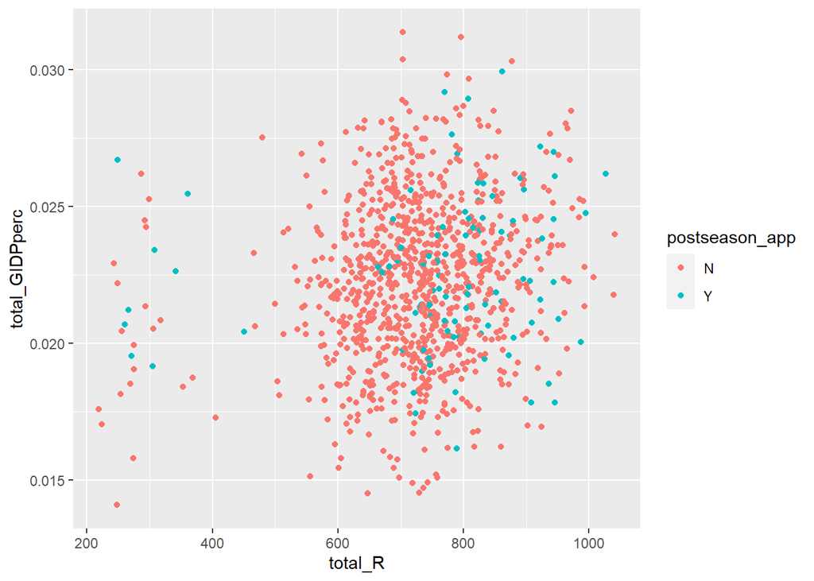

```r
teamsummary %>%
  ggplot(mapping = aes(x = total_R, y = total_GIDPperc)) +
  geom_point(aes(colour = postseason_app))
```

##### G. Salary/Payroll

A team’s payroll is defined as how much money it spends on hiring a player. We have the payroll data for each teams. It’s not completely accurate, as there are some salary data that is not available, but there is data for most players, so this is the best we could do.

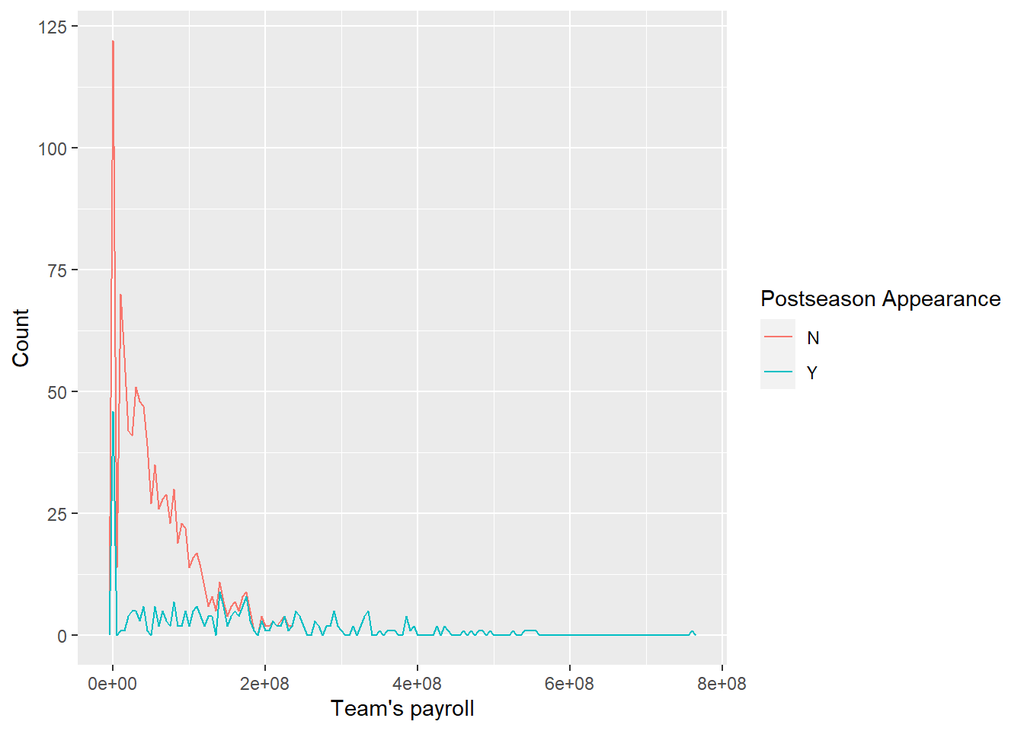

```r
teamsummary %>%
  ggplot(mapping = aes(x = total_salary)) +
  geom_freqpoly(mapping = aes(colour = postseason_app), binwidth = 5000000)+
  labs(x = "Team's payroll", y = "Count", colour = "Postseason Appearance")
```

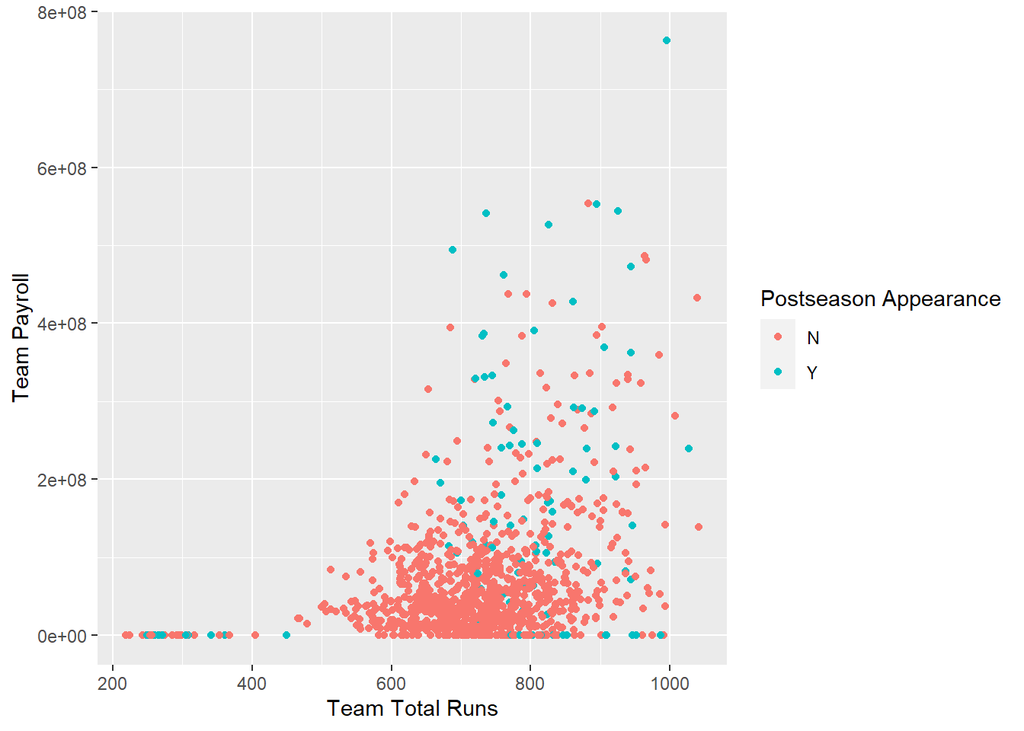

```r
teamsummary %>%
  ggplot(mapping = aes(x = total_R, y = total_salary)) +
  geom_point(aes(colour = postseason_app))+
  labs(x = "Team Total Runs", y = "Team Payroll", colour = "Postseason Appearance")
```

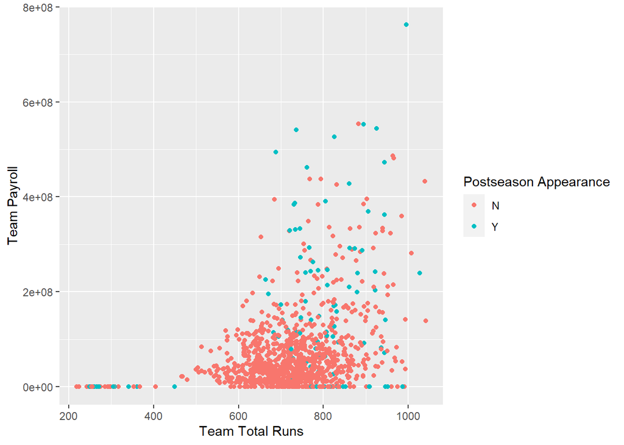

```r
teamsummary %>%
  ggplot(mapping = aes(x = total_R, y = total_salary)) +
  geom_point(aes(colour = postseason_app)) +
  labs(x = "Team Total Runs", y = "Team Payroll", colour = "Postseason Appearance")
```

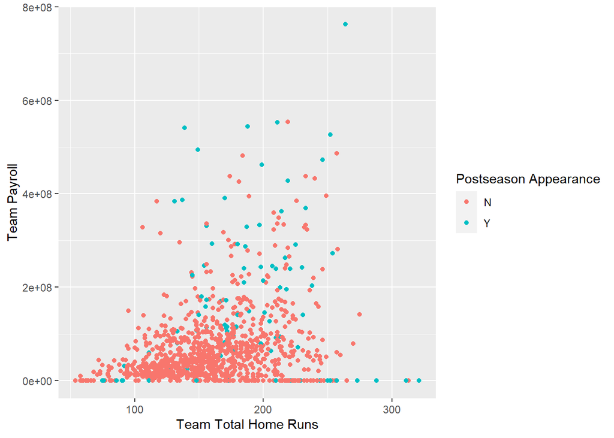

```r
teamsummary %>%
  ggplot(mapping = aes(x = total_HR, y = total_salary)) +
  geom_point(aes(colour = postseason_app)) +
  labs(x = "Team Total Home Runs", y = "Team Payroll", colour = "Postseason Appearance")
```

### Conclusions

In the initial data exploration, EDA of the Lahman dataset confirms the “common sense” trends of baseball. The result from the second part disproves my original hypothesis that the total runs scored is the greatest determinant of a team’s likelihood of reaching the postseason. As determined by EDA, payroll can have a great deal of variance with a lot of outliers. This means that teams with a high payroll would have spent a lot of money on particular players that perform extremely well. Although baseball is known as a team sport that is notoriously difficult to predict the results of, this conclusion suggests that having key individual players can have an immense impact in a team’s performance. The error of my original hypothesis suggests that I overemphasized collective performance over performance due to individual contribution.